# Sign Language Interpreter Aptitude

02 - Change over time analysis

Freya Watkins

University of Birmingham

31 August 2022

# Setup

## Load packages

```r
library(here) # file organisation & folder location
library(tidyverse) # data wrangling & plotting
library(PupillometryR) # raincloud plots
library(sdamr) # simultaneously nudge + jitter plot points
library(plotrix) # calculating standard error
library(scales) # scales on plots
library(patchwork) # combining plots
library(lme4) # linear mixed models
library(sjPlot) # lmm output
library(effsize) # effect sizes
```

### R / package versions used

```r
R.Version()
```

```
## $platform
## [1] "x86_64-w64-mingw32"
##
## $arch
## [1] "x86_64"
##
## $os
## [1] "mingw32"
##
## $system
## [1] "x86_64, mingw32"
##
## $status
## [1] ""
##
## $major
## [1] "4"
##
## $minor
## [1] "0.5"
##
## $year
## [1] "2021"
##
## $month
## [1] "03"
##
## $day
## [1] "31"
##
## $`svn rev`
## [1] "80133"
##
## $language
## [1] "R"
##
## $version.string
## [1] "R version 4.0.5 (2021-03-31)"
##
## $nickname
## [1] "Shake and Throw"
```

```r
packageVersion('here')
```

```
## [1] '1.0.1'
```

```r
packageVersion('tidyverse')
```

```
## [1] '1.3.1'
```

```r
packageVersion('PupillometryR')
```

```
## [1] '0.0.3'
```

```r
packageVersion('sdamr')
```

```
## [1] '0.1.0'
```

```r
packageVersion('plotrix')
```

```
## [1] '3.8.1'
```

```r
packageVersion('scales')
```

```
## [1] '1.2.1'
```

```r
packageVersion('patchwork')
```

```
## [1] '1.1.1'
```

```r
packageVersion('lme4')
```

```
## [1] '1.1.27.1'
```

```r
packageVersion('sjPlot')
```

```
## [1] '2.8.10'
```

```r
packageVersion('effsize')
```

```
## [1] '0.8.1'
```

## Read pre-wrangled data

(see `00-wrangling-setup.Rmd` script)

```r
# here::here() # Check we're working in the right place
apt <- readRDS(here("data", "apt-data.rds"))
apt <- as_tibble(apt)
head(apt)
```

```
## # A tibble: 6 x 46
##   session    group ppt   select~1 selec~2 conti~3 conti~4 L1_bsl self_~5 bsl_y~6
##   <fct>      <fct> <fct> <fct>      <dbl> <fct>     <dbl> <fct>    <dbl>   <dbl>
## 1 pre-degree first S70   selected       1 withdr~       1 0            4      10
## 2 pre-degree first S41   selected       1 withdr~       0 0            1       0
## 3 pre-degree first S63   selected       1 withdr~       0 0            2       2
## 4 pre-degree first S90   selected       1 withdr~       0 0            1       0
## 5 pre-degree first S60   selected       1 withdr~       0 0            1       0
## 6 pre-degree first S96   selected       1 contin~       1 1            5      14
## # ... with 36 more variables: nback_lett <dbl>, nback_spat <dbl>,
## #   nback_comb <dbl>, corsi_bspan <dbl>, corsi_score <dbl>, corsi_corr <dbl>,
## #   corsi_mspan <dbl>, kirk_ceil <dbl>, kirk_raw <dbl>, kirk_acc <dbl>,
## #   kbit_ceil <dbl>, kbit_raw <dbl>, kbit_acc <dbl>, dspan_mem <dbl>,
## #   dspan_corr <dbl>, dspan_time <dbl>, mr2d_acc <dbl>, mr2d_rt <dbl>,
## #   mr2d_sats <dbl>, mr3d_acc <dbl>, mr3d_rt <dbl>, mr3d_sats <dbl>,
## #   bis_tot <dbl>, bis_att <dbl>, bis_mot <dbl>, bis_nplan <dbl>, ...
```

Filter out participants who did not progress beyond interview

```r
apt <- apt %>% filter(selected != 0)
```

Filter out participants with deaf family members / L1 BSL

```r
apt <- apt %>% filter(L1_bsl != 1)
```

Convert data from long format to wide format

```r
apt_wide <- apt %>%
  tidyr::pivot_wider(names_from = session,
                     values_from = c(nback_lett:grade_terp))
```

# Summary tables

### Dual N-Back

```r
# Dual N-Back letter accuracy
apt %>%
  filter(!is.na(nback_lett)) %>%
  group_by(session) %>%
  summarise(nback_lett_mean = mean(nback_lett),
            sd = sd(nback_lett),
            se = std.error(nback_lett))
```

```
## # A tibble: 4 x 4
##   session    nback_lett_mean     sd      se
##   <fct>                <dbl>  <dbl>   <dbl>
## 1 pre-degree           0.710 0.0422 0.00771
## 2 1st year             0.709 0.0599 0.0189
## 3 2nd year             0.745 0.0294 0.00888
## 4 3rd year             0.719 0.0298 0.00992
```

```r
# Dual N-Back spatial accuracy
apt %>%
  filter(!is.na(nback_spat)) %>%
  group_by(session) %>%
  summarise(nback_spat_mean = mean(nback_spat),
            sd = sd(nback_spat),
            se = std.error(nback_spat))
```

```
## # A tibble: 4 x 4
##   session    nback_spat_mean     sd      se
##   <fct>                <dbl>  <dbl>   <dbl>
## 1 pre-degree           0.717 0.0536 0.00978
## 2 1st year             0.736 0.0299 0.00945
## 3 2nd year             0.744 0.0341 0.0103
## 4 3rd year             0.719 0.0395 0.0132
```

```r
# Dual N-Back combined accuracy
apt %>%
  filter(!is.na(nback_comb)) %>%
  group_by(session) %>%
  summarise(nback_comb_mean = mean(nback_comb),
            sd = sd(nback_comb),
            se = std.error(nback_comb))
```

```
## # A tibble: 4 x 4
##   session    nback_comb_mean     sd      se
##   <fct>                <dbl>  <dbl>   <dbl>
## 1 pre-degree           0.713 0.0408 0.00745
## 2 1st year             0.722 0.0382 0.0121
## 3 2nd year             0.745 0.0250 0.00755
## 4 3rd year             0.719 0.0293 0.00978
```

### Corsi Blocks

```r
# Corsi Blocks block span
apt %>%
  filter(!is.na(corsi_bspan)) %>%
  group_by(session) %>%
  summarise(corsi_bspan_mean = mean(corsi_bspan),
            sd = sd(corsi_bspan),
            se = std.error(corsi_bspan))
```

```
## # A tibble: 4 x 4
##   session    corsi_bspan_mean    sd    se
##   <fct>                 <dbl> <dbl> <dbl>
## 1 pre-degree             6.07 1.17  0.214
## 2 1st year               6.45 1.04  0.312
## 3 2nd year               6.45 1.04  0.312
## 4 3rd year               6.11 0.782 0.261
```

```r
# Corsi Blocks total score
apt %>%
  filter(!is.na(corsi_score)) %>%
  group_by(session) %>%
  summarise(corsi_score_mean = mean(corsi_score),
            sd = sd(corsi_score),
            se = std.error(corsi_score))
```

```
## # A tibble: 4 x 4
##   session    corsi_score_mean    sd    se
##   <fct>                 <dbl> <dbl> <dbl>
## 1 pre-degree             54.6  20.3  3.70
## 2 1st year               63.5  16.0  4.81
## 3 2nd year               57.9  17.1  5.15
## 4 3rd year               57.7  14.0  4.68
```

```r
# Corsi Blocks correct responses
apt %>%
  filter(!is.na(corsi_corr)) %>%
  group_by(session) %>%
  summarise(corsi_corr_mean = mean(corsi_corr),
            sd = sd(corsi_corr),
            se = std.error(corsi_corr))
```

```
## # A tibble: 4 x 4
##   session    corsi_corr_mean    sd    se
##   <fct>                <dbl> <dbl> <dbl>
## 1 pre-degree            8.77  1.48 0.270
## 2 1st year              9.73  1.10 0.333
## 3 2nd year              8.82  1.25 0.377
## 4 3rd year              9.33  1.22 0.408
```

```r
# Corsi Blocks memory span
apt %>%
  filter(!is.na(corsi_mspan)) %>%
  group_by(session) %>%
  summarise(corsi_mspan_mean = mean(corsi_mspan),
            sd = sd(corsi_mspan),
            se = std.error(corsi_mspan))
```

```
## # A tibble: 4 x 4
##   session    corsi_mspan_mean    sd    se
##   <fct>                 <dbl> <dbl> <dbl>
## 1 pre-degree             5.38 0.739 0.135
## 2 1st year               5.86 0.552 0.166
## 3 2nd year               5.41 0.625 0.189
## 4 3rd year               5.67 0.612 0.204
```

### Kirklees Sentence Reading

```r
# Kirklees ceiling score
apt %>%
  filter(!is.na(kirk_ceil)) %>%
  group_by(session) %>%
  summarise(kirk_ceil_mean = mean(kirk_ceil),
            sd = sd(kirk_ceil),
            se = std.error(kirk_ceil))
```

```
## # A tibble: 3 x 4
##   session    kirk_ceil_mean    sd    se
##   <fct>               <dbl> <dbl> <dbl>
## 1 pre-degree           38.5  3.75 0.684
## 2 1st year             40.8  1.86 0.619
## 3 2nd year             39    5.66 1.63
```

```r
# Kirklees raw score
apt %>%
  filter(!is.na(kirk_raw)) %>%
  group_by(session) %>%
  summarise(kirk_raw_mean = mean(kirk_raw),
            sd = sd(kirk_raw),
            se = std.error(kirk_raw))
```

```
## # A tibble: 3 x 4
##   session    kirk_raw_mean    sd    se
##   <fct>              <dbl> <dbl> <dbl>
## 1 pre-degree          30.9  5.19 0.948
## 2 1st year            31.6  2.51 0.835
## 3 2nd year            32.4  6.29 1.82
```

```r
# Kirklees accuracy
apt %>%
  filter(!is.na(kirk_acc)) %>%
  group_by(session) %>%
  summarise(kirk_acc_mean = mean(kirk_acc),
            sd = sd(kirk_acc),
            se = std.error(kirk_acc))
```

```
## # A tibble: 3 x 4
##   session    kirk_acc_mean     sd     se
##   <fct>              <dbl>  <dbl>  <dbl>
## 1 pre-degree         0.803 0.114  0.0208
## 2 1st year           0.773 0.0415 0.0138
## 3 2nd year           0.829 0.0945 0.0273
```

### KBIT-2 Matrices

```r
# KBIT-2 Matrices ceiling score
apt %>%
  filter(!is.na(kbit_ceil)) %>%
  group_by(session) %>%
  summarise(kirk_ceil_mean = mean(kbit_ceil),
            sd = sd(kbit_ceil),
            se = std.error(kbit_ceil))
```

```
## # A tibble: 3 x 4
##   session    kirk_ceil_mean    sd    se
##   <fct>               <dbl> <dbl> <dbl>
## 1 pre-degree           41.3  5.25 0.959
## 2 1st year             44.4  1.88 0.626
## 3 2nd year             43.1  3.12 0.900
```

```r
# KBIT-2 Matrices raw score
apt %>%
  filter(!is.na(kbit_raw)) %>%
  group_by(session) %>%
  summarise(kbit_raw_mean = mean(kbit_raw),
            sd = sd(kbit_raw),
            se = std.error(kbit_raw))
```

```
## # A tibble: 3 x 4
##   session    kbit_raw_mean    sd    se
##   <fct>              <dbl> <dbl> <dbl>
## 1 pre-degree          38    5.30 0.967
## 2 1st year            40.8  2.99 0.997
## 3 2nd year            39.7  3.42 0.987
```

```r
# KBIT-2 Matrices accuracy
apt %>%
  filter(!is.na(kbit_acc)) %>%
  group_by(session) %>%
  summarise(kbit_acc_mean = mean(kbit_acc),
            sd = sd(kbit_acc),
            se = std.error(kbit_acc))
```

```
## # A tibble: 3 x 4
##   session    kbit_acc_mean     sd     se
##   <fct>              <dbl>  <dbl>  <dbl>
## 1 pre-degree         0.909 0.0603 0.0110
## 2 1st year           0.882 0.0983 0.0328
## 3 2nd year           0.922 0.0565 0.0163
```

### Digit Span

```r
# Digit Span memory span
apt %>%
  filter(!is.na(dspan_mem)) %>%
  group_by(session) %>%
  summarise(dspan_mem_mean = mean(dspan_mem),
            sd = sd(dspan_mem),
            se = std.error(dspan_mem))
```

```
## # A tibble: 3 x 4
##   session    dspan_mem_mean    sd    se
##   <fct>               <dbl> <dbl> <dbl>
## 1 pre-degree           7.22  1.56 0.367
## 2 2nd year             7.73  1.35 0.407
## 3 3rd year             7.22  1.09 0.364
```

```r
# Digit Span accuracy
apt %>%
  filter(!is.na(dspan_corr)) %>%
  group_by(session) %>%
  summarise(dspan_corr_mean = mean(dspan_corr),
            sd = sd(dspan_corr),
            se = std.error(dspan_corr))
```

```
## # A tibble: 3 x 4
##   session    dspan_corr_mean     sd     se
##   <fct>                <dbl>  <dbl>  <dbl>
## 1 pre-degree           0.718 0.0911 0.0215
## 2 2nd year             0.739 0.0855 0.0258
## 3 3rd year             0.792 0.0458 0.0153
```

### 2D Mental Rotation

```r
# 2D Mental Rotation accuracy
apt %>%
  filter(!is.na(mr2d_acc)) %>%
  group_by(session) %>%
  summarise(mr2d_acc_mean = mean(mr2d_acc),
            sd = sd(mr2d_acc),
            se = std.error(mr2d_acc))
```

```
## # A tibble: 4 x 4
##   session    mr2d_acc_mean     sd     se
##   <fct>              <dbl>  <dbl>  <dbl>
## 1 pre-degree         0.907 0.0682 0.0227
## 2 1st year           0.916 0.0691 0.0230
## 3 2nd year           0.822 0.118  0.0356
## 4 3rd year           0.839 0.0715 0.0238
```

```r
# 2D Mental Rotation reaction time
apt %>%
  filter(!is.na(mr2d_rt)) %>%
  group_by(session) %>%
  summarise(mr2d_rt_mean = mean(mr2d_rt),
            sd = sd(mr2d_rt),
            se = std.error(mr2d_rt))
```

```
## # A tibble: 4 x 4
##   session    mr2d_rt_mean    sd    se
##   <fct>             <dbl> <dbl> <dbl>
## 1 pre-degree        2921.  739.  246.
## 2 1st year          2223.  546.  182.
## 3 2nd year          2373.  906.  273.
## 4 3rd year          2306.  534.  178.
```

```r
# 2D Mental Rotation speed-accuracy trade-off score
apt %>%
  filter(!is.na(mr2d_sats)) %>%
  group_by(session) %>%
  summarise(mr2d_sats_mean = mean(mr2d_sats),
            sd = sd(mr2d_sats),
            se = std.error(mr2d_sats))
```

```
## # A tibble: 4 x 4
##   session    mr2d_sats_mean    sd    se
##   <fct>               <dbl> <dbl> <dbl>
## 1 pre-degree          0.472 0.959 0.320
## 2 1st year            1.05  0.672 0.224
## 3 2nd year            0.133 1.03  0.311
## 4 3rd year            0.329 0.620 0.207
```

### 3D Mental Rotation

```r
# 3D Mental Rotation accuracy
apt %>%
  filter(!is.na(mr3d_acc)) %>%
  group_by(session) %>%
  summarise(mr3d_acc_mean = mean(mr3d_acc),
            sd = sd(mr3d_acc),
            se = std.error(mr3d_acc))
```

```
## # A tibble: 4 x 4
##   session    mr3d_acc_mean     sd     se
##   <fct>              <dbl>  <dbl>  <dbl>
## 1 pre-degree         0.632 0.201  0.0439
## 2 1st year           0.795 0.0636 0.045
## 3 2nd year           0.76  0.148  0.0411
## 4 3rd year           0.756 0.154  0.0514
```

```r
# 3D Mental Rotation reaction time
apt %>%
  filter(!is.na(mr3d_rt)) %>%
  group_by(session) %>%
  summarise(mr3d_rt_mean = mean(mr3d_rt),
            sd = sd(mr3d_rt),
            se = std.error(mr3d_rt))
```

```
## # A tibble: 4 x 4
##   session    mr3d_rt_mean    sd    se
##   <fct>             <dbl> <dbl> <dbl>
## 1 pre-degree        3226.  607.  132.
## 2 1st year          2706.  435.  307.
## 3 2nd year          2416.  490.  136.
## 4 3rd year          2339.  317.  106.
```

```r
# 3D Mental Rotation speed-accuracy trade-off score
apt %>%
  filter(!is.na(mr3d_sats)) %>%
  group_by(session) %>%
  summarise(mr3d_sats_mean = mean(mr3d_sats),
            sd = sd(mr3d_sats),
            se = std.error(mr3d_sats))
```

```
## # A tibble: 4 x 4
##   session    mr3d_sats_mean    sd    se
##   <fct>               <dbl> <dbl> <dbl>
## 1 pre-degree         -1.07  1.67  0.365
## 2 1st year            0.649 0.322 0.228
## 3 2nd year            0.905 1.16  0.322
## 4 3rd year            1.00  0.983 0.328
```

### Barratt Impulsiveness Scale

```r
# BIS total score
apt %>%
  filter(!is.na(bis_tot)) %>%
  group_by(session) %>%
  summarise(bis_tot_mean = mean(bis_tot),
            sd = sd(bis_tot),
            se = std.error(bis_tot))
```

```
## # A tibble: 3 x 4
##   session  bis_tot_mean    sd    se
##   <fct>           <dbl> <dbl> <dbl>
## 1 1st year         56    11.3  8
## 2 2nd year         66.8  11.8  3.26
## 3 3rd year         60.1  10.2  3.39
```

```r
# BIS attention sub-score
apt %>%
  filter(!is.na(bis_att)) %>%
  group_by(session) %>%
  summarise(bis_att_mean = mean(bis_att),
            sd = sd(bis_att),
            se = std.error(bis_att))
```

```
## # A tibble: 3 x 4
##   session  bis_att_mean    sd    se
##   <fct>           <dbl> <dbl> <dbl>
## 1 1st year         12.5  3.54  2.5
## 2 2nd year         18.9  5.35  1.48
## 3 3rd year         17    4.80  1.60
```

```r
# BIS motor sub-score
apt %>%
  filter(!is.na(bis_mot)) %>%
  group_by(session) %>%
  summarise(bis_mot_mean = mean(bis_mot),
            sd = sd(bis_mot),
            se = std.error(bis_mot))
```

```
## # A tibble: 3 x 4
##   session  bis_mot_mean    sd    se
##   <fct>           <dbl> <dbl> <dbl>
## 1 1st year         16    1.41  1
## 2 2nd year         23.2  5.15  1.43
## 3 3rd year         20.6  3.54  1.18
```

```r
# BIS non-planning sub-score
apt %>%
  filter(!is.na(bis_nplan)) %>%
  group_by(session) %>%
  summarise(bis_nplan_mean = mean(bis_nplan),
            sd = sd(bis_nplan),
            se = std.error(bis_nplan))
```

```
## # A tibble: 3 x 4
##   session  bis_nplan_mean    sd    se
##   <fct>             <dbl> <dbl> <dbl>
## 1 1st year           27.5  6.36  4.5
## 2 2nd year           24.7  4.94  1.37
## 3 3rd year           22.6  4.50  1.50
```

### Other predictors

# Plots

Let’s plot the changes in the linguistic & cognitive predictor assessments over time

```r
# set up a theme for the plots
theme_details <- theme_bw() +
    theme(panel.grid.major = element_blank(),
          panel.grid.minor = element_blank(),
          panel.border = element_rect(colour = "black", size = 0.5),
          plot.title.position = "plot",
          plot.title = element_text(size = 16, face = "bold"),
          axis.title.x = element_text(size = 14, face = "bold"),
          axis.title.y = element_text(size = 14, face = "bold"),
          axis.text.x = element_text(size = 14, colour = "black"),
          axis.text.y = element_text(size = 14, colour = "black"),
          legend.position = "none")
pd <- position_dodge(0.5)
```

### Dual N-Back

How does performance on the Dual N-Back task change over time?

#### Letter matching

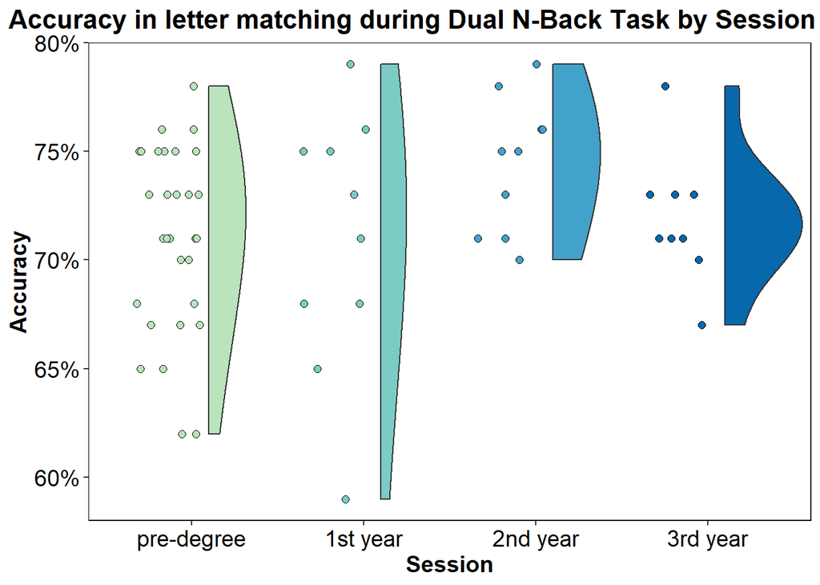

```r
# Raincloud plot
( R1 <- apt %>%
  filter(!is.na(nback_lett)) %>%
  ggplot(aes(x = session, y = nback_lett, group = session, fill = session)) +
  geom_flat_violin(position = position_nudge(x = .1, y = 0),
                   adjust = 2, trim = TRUE, alpha = 1) +
  geom_point(position = position_jitternudge(seed=42,jitter.width = .4, nudge.x = -.15),
                        size = 2, shape = 21) +
  scale_fill_manual(values = c("#bae4bc", "#7bccc4", "#43a2ca", "#0868ac")) +
  scale_y_continuous(labels = percent_format(accuracy=1)) +
  labs(title = "Accuracy in letter matching during Dual N-Back Task by Session",
       x = "Session", y = "Accuracy") +
  theme_details )
```

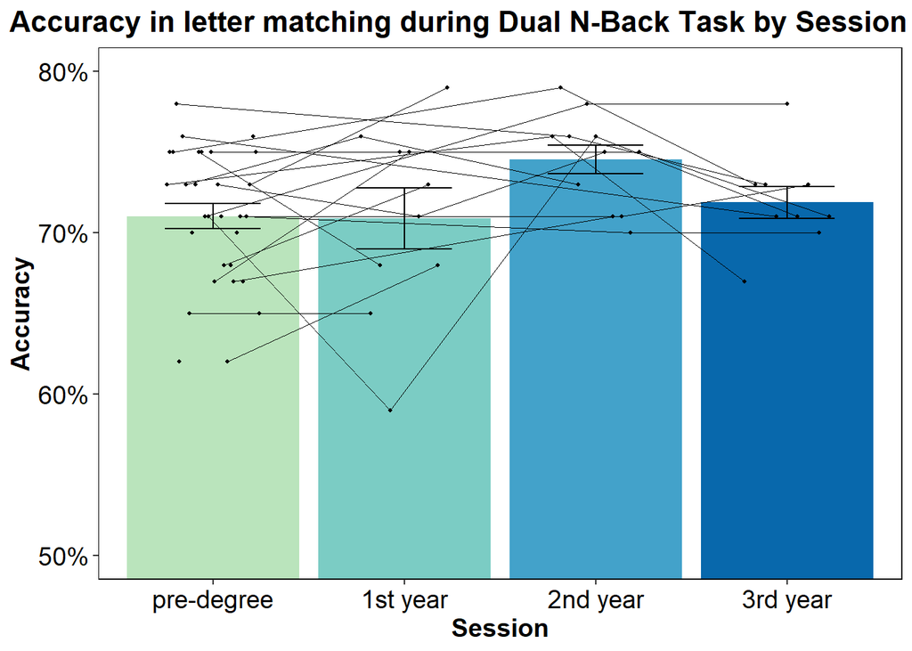

```r
# Jitter plot
J1 <- apt %>%
  group_by(session) %>%
  filter(!is.na(nback_lett)) %>%
  summarize(mean=mean(nback_lett), sd = sd(nback_lett), se=std.error(nback_lett)) %>%
  ggplot(aes(x = session, y = mean, fill = session)) +
  geom_bar(stat = 'identity', position = position_dodge()) +
  coord_cartesian(ylim = c(0.5, 0.8)) +
  theme_minimal() +
  scale_y_continuous(labels = percent_format(accuracy=1)) +
  scale_fill_manual(values = c("#bae4bc", "#7bccc4", "#43a2ca", "#0868ac")) +
  labs(title = "Accuracy in letter matching during Dual N-Back Task by Session",
       x = "Session", y = "Accuracy")

limits <- aes(ymax = mean + se, ymin = mean - se)
J2 <- J1 + geom_errorbar(position = position_dodge(),
                          limits, size = 0.5, width = 0.5) +
  scale_y_continuous(labels = percent_format(accuracy=1))

indiv <- apt %>%
  filter(!is.na(nback_lett)) %>%
  group_by(session, ppt) %>%
  summarise(mean = mean(nback_lett)) #, sd = sd(nback_lett)) # requires trial level data

J3 <- J2 + geom_point(data=indiv, aes(group = ppt), size = 0.8,
                       shape = 19, position = pd) +
    geom_line(data = indiv, aes(group = ppt),
                      size = 0.1, position = pd)

( J4 <- J3 + theme_details )
```

#### Spatial matching

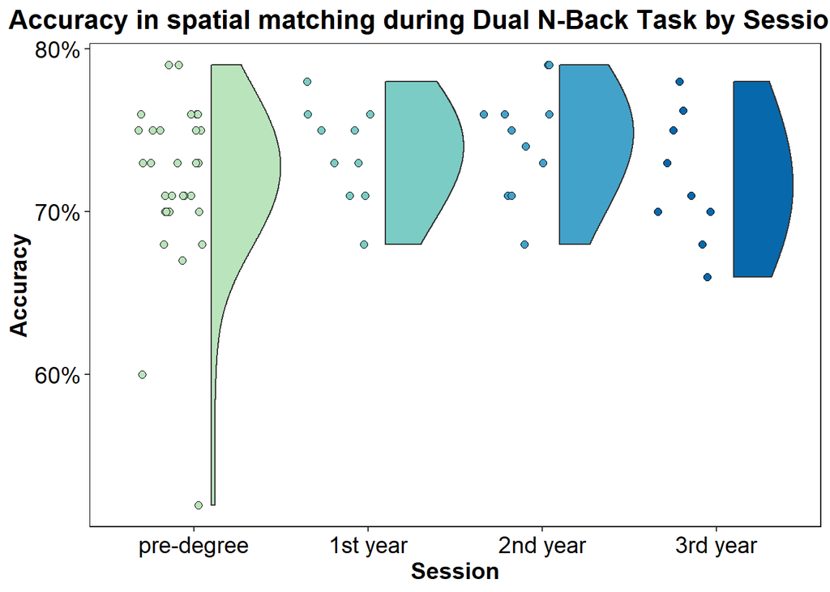

```r
# Raincloud plot
( R1 <- apt %>%
  filter(!is.na(nback_spat)) %>%
  ggplot(aes(x = session, y = nback_spat, group = session, fill = session)) +
  geom_flat_violin(position = position_nudge(x = .1, y = 0),
                   adjust = 2, trim = TRUE, alpha = 1) +
  geom_point(position = position_jitternudge(seed=42,jitter.width = .4, nudge.x = -.15),
                        size = 2, shape = 21) +
  scale_fill_manual(values = c("#bae4bc", "#7bccc4", "#43a2ca", "#0868ac")) +
  scale_y_continuous(labels = scales::percent_format(accuracy = 1L)) +
  labs(title = "Accuracy in spatial matching during Dual N-Back Task by Session",
       x = "Session", y = "Accuracy") +
  theme_details )
```

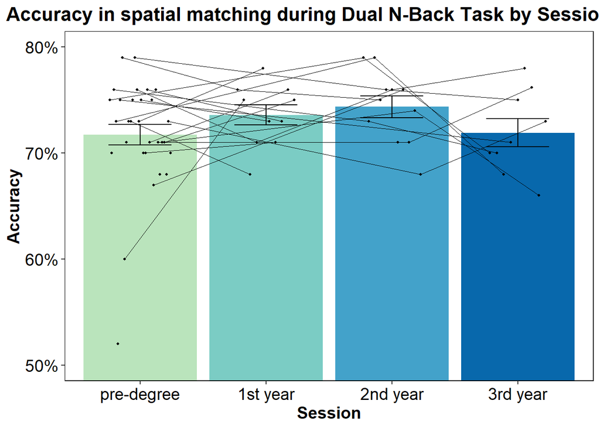

```r
# Jitter plot
J1 <- apt %>%
  group_by(session) %>%
  filter(!is.na(nback_spat)) %>%
  summarize(mean=mean(nback_spat), sd = sd(nback_spat), se=std.error(nback_spat)) %>%
  ggplot(aes(x = session, y = mean, fill = session)) +
  geom_bar(stat = 'identity', position = position_dodge()) +
  coord_cartesian(ylim = c(0.5, 0.8)) +
  theme_minimal() +
  scale_y_continuous(labels = percent_format(accuracy=1)) +
  scale_fill_manual(values = c("#bae4bc", "#7bccc4", "#43a2ca", "#0868ac")) +
  labs(title = "Accuracy in spatial matching during Dual N-Back Task by Session",
       x = "Session", y = "Accuracy")

limits <- aes(ymax = mean + se, ymin = mean - se)
J2 <- J1 + geom_errorbar(position = position_dodge(),
                          limits, size = 0.5, width = 0.5) +
  scale_y_continuous(labels = percent_format(accuracy=1))

indiv <- apt %>%
  filter(!is.na(nback_spat)) %>%
  group_by(session, ppt) %>%
  summarise(mean = mean(nback_spat)) #, sd = sd(nback_spat)) # requires trial-level data

J3 <- J2 + geom_point(data=indiv, aes(group = ppt), size = 0.8,
                       shape = 19, position = pd) +
    geom_line(data = indiv, aes(group = ppt),
                      size = 0.1, position = pd)

( J4 <- J3 + theme_details )
```

#### Combined accuracy

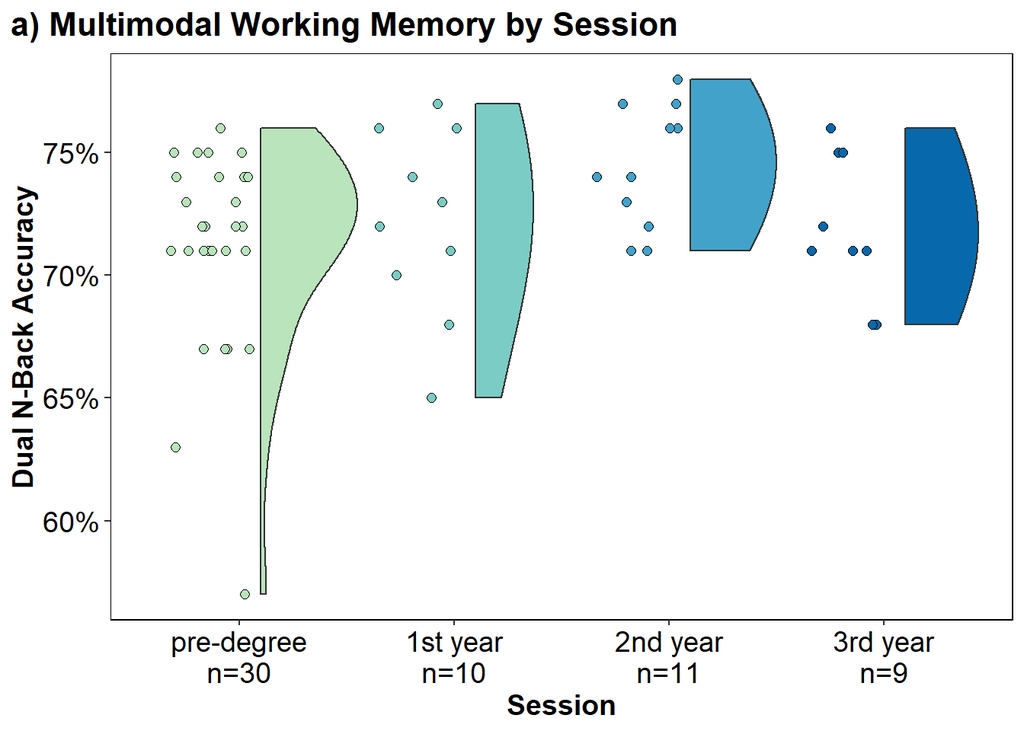

```r
## Raincloud plot
( fig3a <- apt %>%
  filter(!is.na(nback_comb)) %>%
  ggplot(aes(x = session, y = nback_comb, group = session, fill = session)) +
  geom_flat_violin(position = position_nudge(x = .1, y = 0),
                   adjust = 2, trim = TRUE, alpha = 1) +
  geom_point(position = position_jitternudge(seed=42,jitter.width = .4, nudge.x = -.15),
                        size = 2, shape = 21) +
  scale_fill_manual(values = c("#bae4bc", "#7bccc4", "#43a2ca", "#0868ac")) +
  scale_x_discrete(labels = c('pre-degree\nn=30', '1st year\nn=10',
                              '2nd year\nn=11', '3rd year\nn=9')) +
  scale_y_continuous(labels = percent_format(accuracy=1)) +
  labs(title = "a) Multimodal Working Memory by Session",
       x = "Session", y = "Dual N-Back Accuracy") +
  theme_details )
```

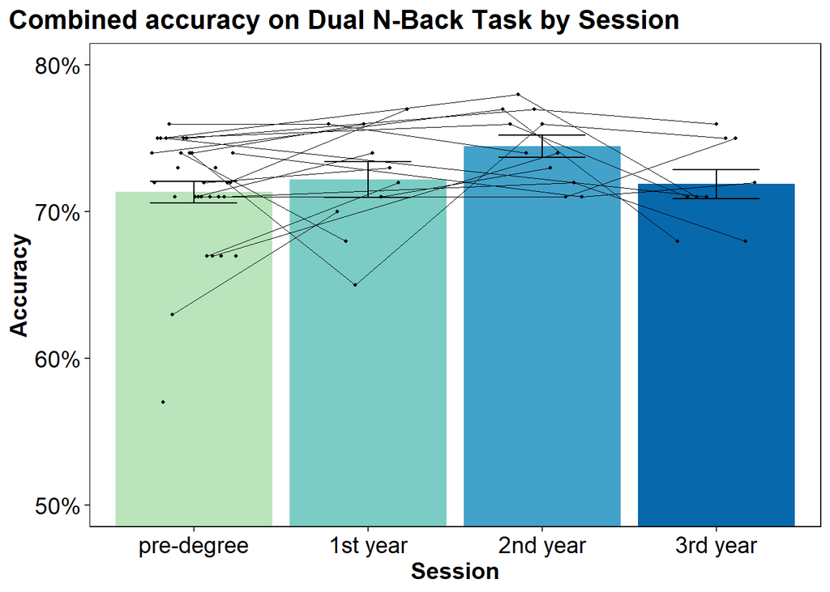

```r
# Jitter plot
J1 <- apt %>%
  group_by(session) %>%
  filter(!is.na(nback_comb)) %>%
  summarize(mean=mean(nback_comb), sd = sd(nback_comb), se=std.error(nback_comb)) %>%
  ggplot(aes(x = session, y = mean, fill = session)) +
  geom_bar(stat = 'identity', position = position_dodge()) +
  coord_cartesian(ylim = c(0.5, 0.8)) +
  theme_minimal() +
  scale_y_continuous(labels = percent_format(accuracy=1)) +
  scale_fill_manual(values = c("#bae4bc", "#7bccc4", "#43a2ca", "#0868ac")) +
  labs(title = "Combined accuracy on Dual N-Back Task by Session",
       x = "Session", y = "Accuracy")

limits <- aes(ymax = mean + se, ymin = mean - se)
J2 <- J1 + geom_errorbar(position = position_dodge(),
                          limits, size = 0.5, width = 0.5) +
  scale_y_continuous(labels = percent_format(accuracy=1))

indiv <- apt %>%
  filter(!is.na(nback_comb)) %>%
  group_by(session, ppt) %>%
  summarise(mean = mean(nback_comb)) #, sd = sd(nback_comb)) # requires trial-level data

J3 <- J2 + geom_point(data=indiv, aes(group = ppt), size = 0.8,
                       shape = 19, position = pd) +
    geom_line(data = indiv, aes(group = ppt),
                      size = 0.1, position = pd)

( J4 <- J3 + theme_details )
```

### Corsi Blocks

How does performance on the Corsi Blocks task change over time?

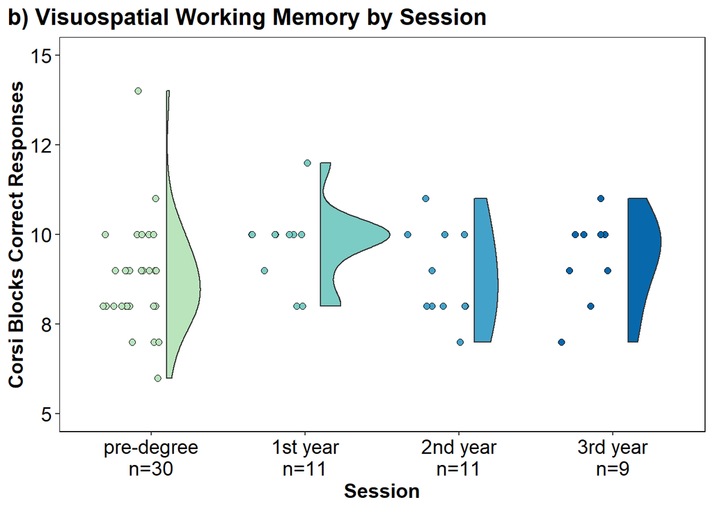

```r
# Raincloud plot
( fig3b <- apt %>%
  filter(!is.na(corsi_corr)) %>%
  ggplot(aes(x = session, y = corsi_corr, group = session, fill = session)) +
  geom_flat_violin(position = position_nudge(x = .1, y = 0),
                   adjust = 2, trim = TRUE, alpha = 1) +
  geom_point(position = position_jitternudge(seed=42,jitter.width = .4, nudge.x = -.15),
                        size = 2, shape = 21) +
  coord_cartesian(ylim = c(5, 15)) +
  scale_fill_manual(values = c("#bae4bc", "#7bccc4", "#43a2ca", "#0868ac")) +
  scale_x_discrete(labels = c('pre-degree\nn=30', '1st year\nn=11',
                              '2nd year\nn=11', '3rd year\nn=9')) +
  scale_y_continuous(labels = scales::number_format(accuracy = 1)) +
  labs(title = "b) Visuospatial Working Memory by Session",
       x = "Session", y = "Corsi Blocks Correct Responses") +
  theme_details )
```

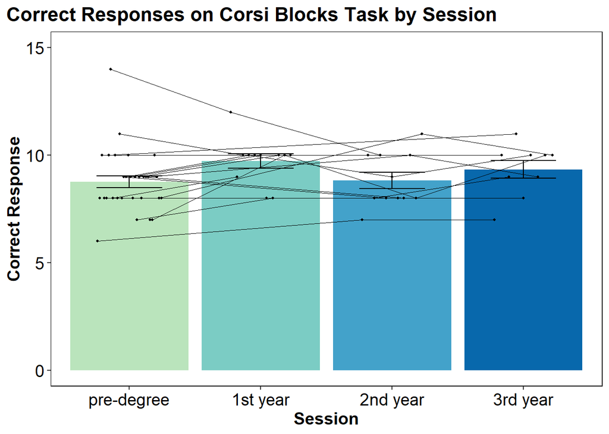

```r
# Jitter plot
J1 <- apt %>%
  group_by(session) %>%
  filter(!is.na(corsi_corr)) %>%
  summarize(mean=mean(corsi_corr), sd = sd(corsi_corr), se=std.error(corsi_corr)) %>%
  ggplot(aes(x = session, y = mean, fill = session)) +
  coord_cartesian(ylim = c(0, 15)) +
  geom_bar(stat = 'identity', position = position_dodge()) +
  theme_minimal() +
  scale_fill_manual(values = c("#bae4bc", "#7bccc4", "#43a2ca", "#0868ac")) +
  labs(title = "Correct Responses on Corsi Blocks Task by Session",
       x = "Session", y = "Correct Response")

limits <- aes(ymax = mean + se, ymin = mean - se)
J2 <- J1 + geom_errorbar(position = position_dodge(),
                          limits, size = 0.5, width = 0.5)

indiv <- apt %>%
  filter(!is.na(corsi_corr)) %>%
  group_by(session, ppt) %>%
  summarise(mean = mean(corsi_corr)) #, sd = sd(corsi_corr)) # requires trial-level data

J3 <- J2 + geom_point(data=indiv, aes(group = ppt), size = 0.8,
                       shape = 19, position = pd) +
    geom_line(data = indiv, aes(group = ppt),
                      size = 0.1, position = pd)

( J4 <- J3 + theme_details )
```

### Kirklees Sentence Reading

How does performance on the Kirklees Sentence Reading task change over time?

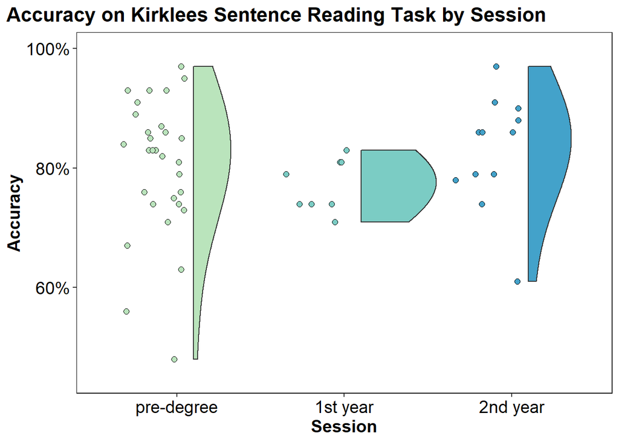

```r
# Raincloud plot
( R1 <- apt %>%
  filter(!is.na(kirk_acc)) %>%
  ggplot(aes(x = session, y = kirk_acc, group = session, fill = session)) +
  geom_flat_violin(position = position_nudge(x = .1, y = 0),
                   adjust = 2, trim = TRUE, alpha = 1) +
  geom_point(position = position_jitternudge(seed=42,jitter.width = .4, nudge.x = -.15),
                        size = 2, shape = 21) +
  coord_cartesian(ylim = c(0.45, 1)) +
  scale_fill_manual(values = c("#bae4bc", "#7bccc4", "#43a2ca", "#0868ac")) +
  scale_y_continuous(labels = percent_format(accuracy=1)) +
  labs(title = "Accuracy on Kirklees Sentence Reading Task by Session",
       x = "Session", y = "Accuracy") +
  theme_details )
```

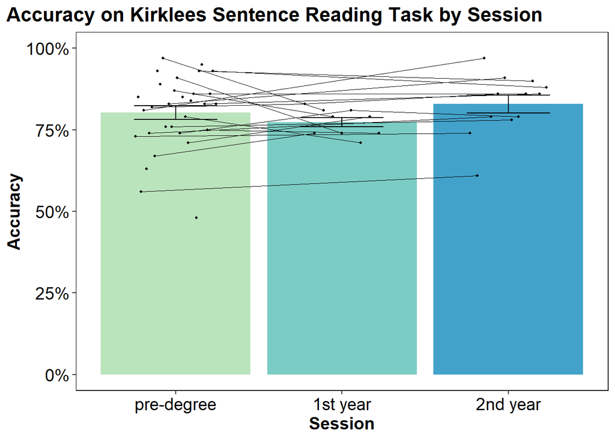

```r
# Jitter plot
J1 <- apt %>%
  group_by(session) %>%
  filter(!is.na(kirk_acc)) %>%
  summarize(mean=mean(kirk_acc), sd = sd(kirk_acc), se=std.error(kirk_acc)) %>%
  ggplot(aes(x = session, y = mean, fill = session)) +
  coord_cartesian(ylim = c(0, 1)) +
  geom_bar(stat = 'identity', position = position_dodge()) +
  theme_minimal() +
  scale_fill_manual(values = c("#bae4bc", "#7bccc4", "#43a2ca", "#0868ac")) +
  scale_y_continuous(labels = percent_format(accuracy=1)) +
  labs(title = "Accuracy on Kirklees Sentence Reading Task by Session",
       x = "Session", y = "Accuracy")

limits <- aes(ymax = mean + se, ymin = mean - se)
J2 <- J1 + geom_errorbar(position = position_dodge(),
                          limits, size = 0.5, width = 0.5)

indiv <- apt %>%
  filter(!is.na(kirk_acc)) %>%
  group_by(session, ppt) %>%
  summarise(mean = mean(kirk_acc)) #, sd = sd(kirk_acc) # requires trial-level data

J3 <- J2 + geom_point(data=indiv, aes(group = ppt), size = 0.8,
                       shape = 19, position = pd) +
    geom_line(data = indiv, aes(group = ppt),
                      size = 0.1, position = pd)

( J4 <- J3 + theme_details )
```

### KBIT-2 Matrices

How does performance on the KBIT-2 Matrices task change over time?

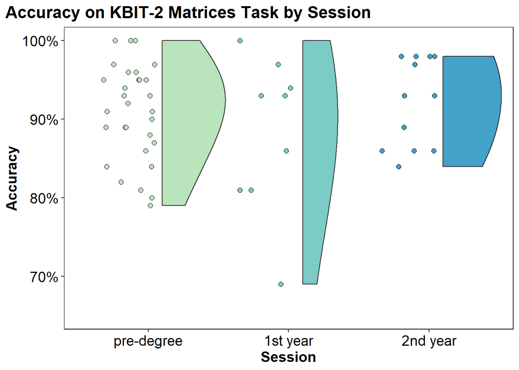

```r
# Raincloud plot
( R1 <- apt %>%
  filter(!is.na(kbit_acc)) %>%
  ggplot(aes(x = session, y = kbit_acc, group = session, fill = session)) +
  geom_flat_violin(position = position_nudge(x = .1, y = 0),
                   adjust = 2, trim = TRUE, alpha = 1) +
  geom_point(position = position_jitternudge(seed=42,jitter.width = .4, nudge.x = -.15),
                        size = 2, shape = 21) +
  coord_cartesian(ylim = c(.65, 1)) +
  scale_fill_manual(values = c("#bae4bc", "#7bccc4", "#43a2ca", "#0868ac")) +
  scale_y_continuous(labels = percent_format(accuracy=1)) +
  labs(title = "Accuracy on KBIT-2 Matrices Task by Session",
       x = "Session", y = "Accuracy") +
  theme_details )
```

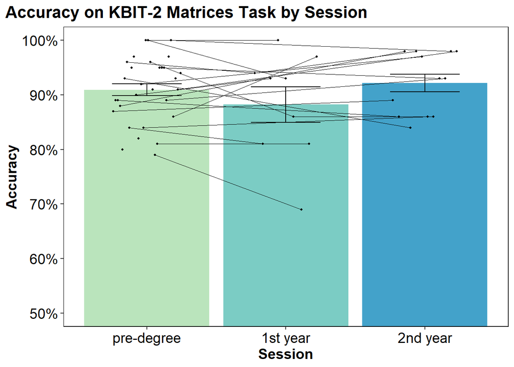

```r
# Jitter plot
J1 <- apt %>%
  group_by(session) %>%
  filter(!is.na(kbit_acc)) %>%
  summarize(mean=mean(kbit_acc),
            sd = sd(kbit_acc), se=std.error(kbit_acc)) %>%
  ggplot(aes(x = session, y = mean, fill = session)) +
  coord_cartesian(ylim = c(.5, 1)) +
  geom_bar(stat = 'identity', position = position_dodge()) +
  theme_minimal() +
  scale_fill_manual(values = c("#bae4bc", "#7bccc4", "#43a2ca", "#0868ac")) +
  scale_y_continuous(labels = percent_format(accuracy=1)) +
  labs(title = "Accuracy on KBIT-2 Matrices Task by Session",
       x = "Session", y = "Accuracy")

limits <- aes(ymax = mean + se, ymin = mean - se)
J2 <- J1 + geom_errorbar(position = position_dodge(),
                          limits, size = 0.5, width = 0.5)

indiv <- apt %>%
  filter(!is.na(kbit_acc)) %>%
  group_by(session, ppt) %>%
  summarise(mean = mean(kbit_acc)) #, sd = sd(kbit_acc) # requires trial-level data

J3 <- J2 + geom_point(data=indiv, aes(group = ppt), size = 0.8,
                       shape = 19, position = pd) +
    geom_line(data = indiv, aes(group = ppt),
                      size = 0.1, position = pd)

( J4 <- J3 + theme_details )
```

### Digit Span

How does performance on the Digit Span task change over time?

#### Accuracy

[figure not shown]

```r
# Raincloud plot
( fig3c <- apt %>%
  #filter(!is.na(dspan_corr)) %>%
  ggplot(aes(x = session, y = dspan_corr, group = session, fill = session)) +
  geom_flat_violin(position = position_nudge(x = .1, y = 0),
                   adjust = 2, trim = TRUE, alpha = 1) +
  geom_point(position = position_jitternudge(seed=42,jitter.width = .4, nudge.x = -.15),
                        size = 2, shape = 21) +
  coord_cartesian(ylim = c(0.5, 0.9)) +
  scale_fill_manual(values = c("#7bccc4", "#43a2ca", "#0868ac", "#bae4bc")) +
  scale_x_discrete(labels = c('pre-degree\nn=18', '1st year\nn=0',
                              '2nd year\nn=11', '3rd year\nn=9')) +
  scale_y_continuous(labels = scales::percent_format(accuracy = 1L)) +
  labs(title = "c) Auditory Working Memory by Session",
       x = "Session", y = "Digit Span Accuracy") +
  theme_details )
```

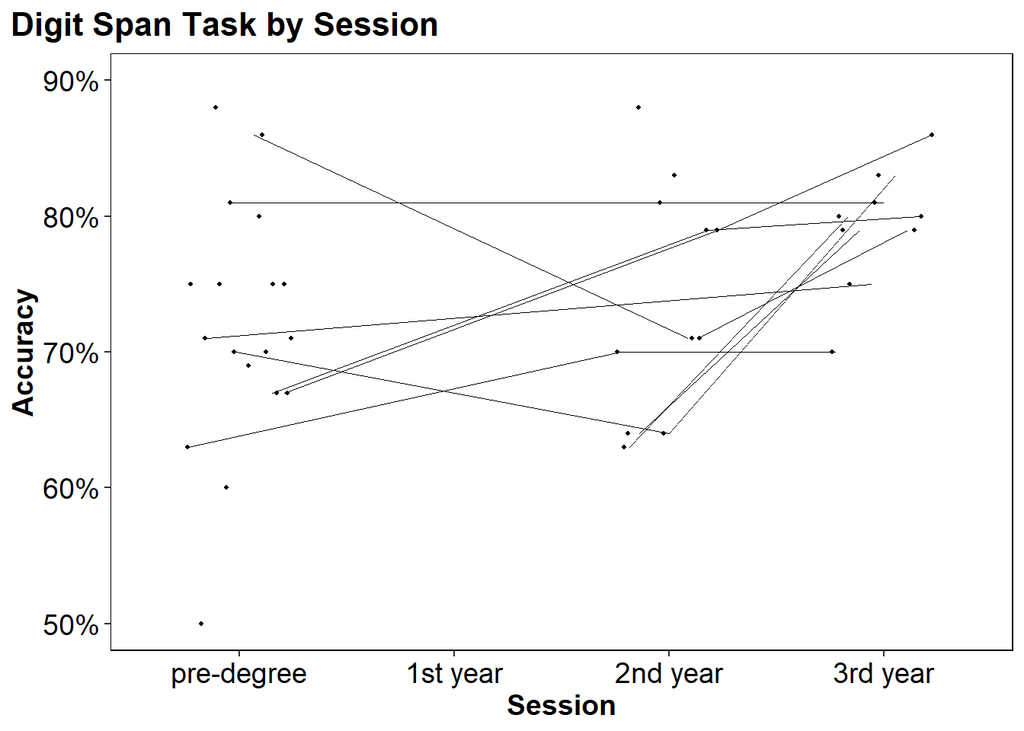

```r
# Jitter plot
J1 <- apt %>%
  group_by(session) %>%
  #filter(!is.na(dspan_corr)) %>%
  summarize(mean=mean(dspan_corr),
            sd = sd(dspan_corr), se=std.error(dspan_corr)) %>%
  ggplot(aes(x = session, y = mean, fill = session)) +
  coord_cartesian(ylim = c(0.5, 0.9)) +
  geom_bar(stat = 'identity', position = position_dodge()) +
  theme_minimal() +
  scale_fill_manual(values = c("#bae4bc", "#7bccc4", "#43a2ca", "#0868ac")) +
  scale_y_continuous(labels = scales::percent_format(accuracy = 1L)) +
  labs(title = "Digit Span Task by Session",
       x = "Session", y = "Accuracy")

limits <- aes(ymax = mean + se, ymin = mean - se)
J2 <- J1 + geom_errorbar(position = position_dodge(),
                          limits, size = 0.5, width = 0.5)

indiv <- apt %>%
  #filter(!is.na(dspan_corr)) %>%
  group_by(session, ppt) %>%
  summarise(mean = mean(dspan_corr)) #, sd = sd(dspan_corr)) # requires trial-level data

indiv2 <- apt %>%
  filter(!is.na(dspan_corr)) %>%
  group_by(session, ppt) %>%
  summarise(mean = mean(dspan_corr)) #, sd = sd(dspan_corr)) # requires trial-level data

J3 <- J2 + geom_point(data=indiv, aes(group = ppt), size = 0.8,
                       shape = 19, position = pd) +
    geom_line(data = indiv2, aes(group = ppt),
                      size = 0.1, position = pd)

( J4 <- J3 + theme_details )
```

#### Memory Span

[figure not shown]

```r
# Raincloud plot
( R1 <- apt %>%
  #filter(!is.na(dspan_mem)) %>%
  ggplot(aes(x = session, y = dspan_mem, group = session, fill = session)) +
  geom_flat_violin(position = position_nudge(x = .1, y = 0),
                   adjust = 2, trim = TRUE, alpha = 1) +
  geom_point(position = position_jitternudge(seed=42,jitter.width = .4, nudge.x = -.15),
                        size = 2, shape = 21) +
  coord_cartesian(ylim = c(4, 11)) +
  scale_fill_manual(values = c("#7bccc4", "#43a2ca", "#0868ac", "#bae4bc")) +
  labs(title = "Memory Span on Digit Span Task by Session",
       x = "Session", y = "Memory Span") +
  theme_details )
```

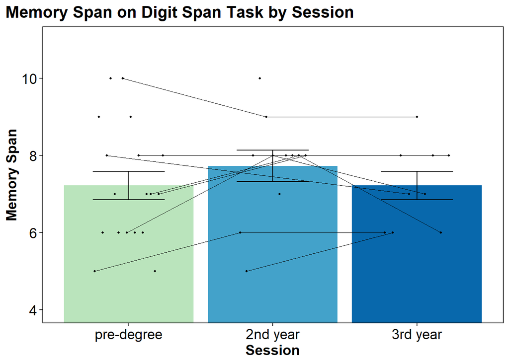

```r
# Jitter plot
J1 <- apt %>%
  group_by(session) %>%
  filter(!is.na(dspan_mem)) %>%
  summarize(mean=mean(dspan_mem),
            sd = sd(dspan_mem), se=std.error(dspan_mem)) %>%
  ggplot(aes(x = session, y = mean, fill = session)) +
  coord_cartesian(ylim = c(0, 8)) +
  geom_bar(stat = 'identity', position = position_dodge()) +
  theme_minimal() +
  scale_fill_manual(values = c("#bae4bc", "#43a2ca", "#0868ac")) +
  coord_cartesian(ylim = c(4, 11)) +
  labs(title = "Memory Span on Digit Span Task by Session",
       x = "Session", y = "Memory Span")

limits <- aes(ymax = mean + se, ymin = mean - se)
J2 <- J1 + geom_errorbar(position = position_dodge(),
                          limits, size = 0.5, width = 0.5)

indiv <- apt %>%
  filter(!is.na(dspan_mem)) %>%
  group_by(session, ppt) %>%
  summarise(mean = mean(dspan_mem)) #, sd = sd(dspan_mem)) # requires trial-level data

J3 <- J2 + geom_point(data=indiv, aes(group = ppt), size = 0.8,
                       shape = 19, position = pd) +
    geom_line(data = indiv, aes(group = ppt),
                      size = 0.1, position = pd)

( J4 <- J3 + theme_details )
```

### 2D Mental Rotation

How does performance on the 2D Mental Rotation task change over time?

#### Accuracy

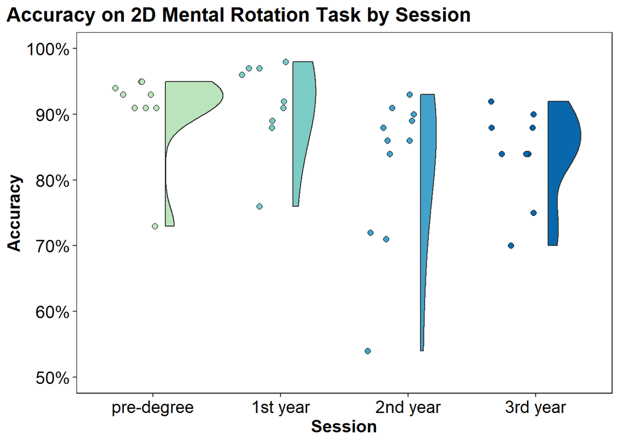

```r
# Raincloud plot
( R1 <- apt %>%
  filter(!is.na(mr2d_acc)) %>%
  ggplot(aes(x = session, y = mr2d_acc, group = session, fill = session)) +
  geom_flat_violin(position = position_nudge(x = .1, y = 0),
                   adjust = 2, trim = TRUE, alpha = 1) +
  geom_point(position = position_jitternudge(seed=42,jitter.width = .4, nudge.x = -.15),
                        size = 2, shape = 21) +
  coord_cartesian(ylim = c(0.5, 1)) +
  scale_fill_manual(values = c("#bae4bc", "#7bccc4", "#43a2ca", "#0868ac")) +
  scale_y_continuous(labels = scales::percent_format(accuracy = 1L)) +
  labs(title = "Accuracy on 2D Mental Rotation Task by Session",
       x = "Session", y = "Accuracy") +
  theme_details )
```

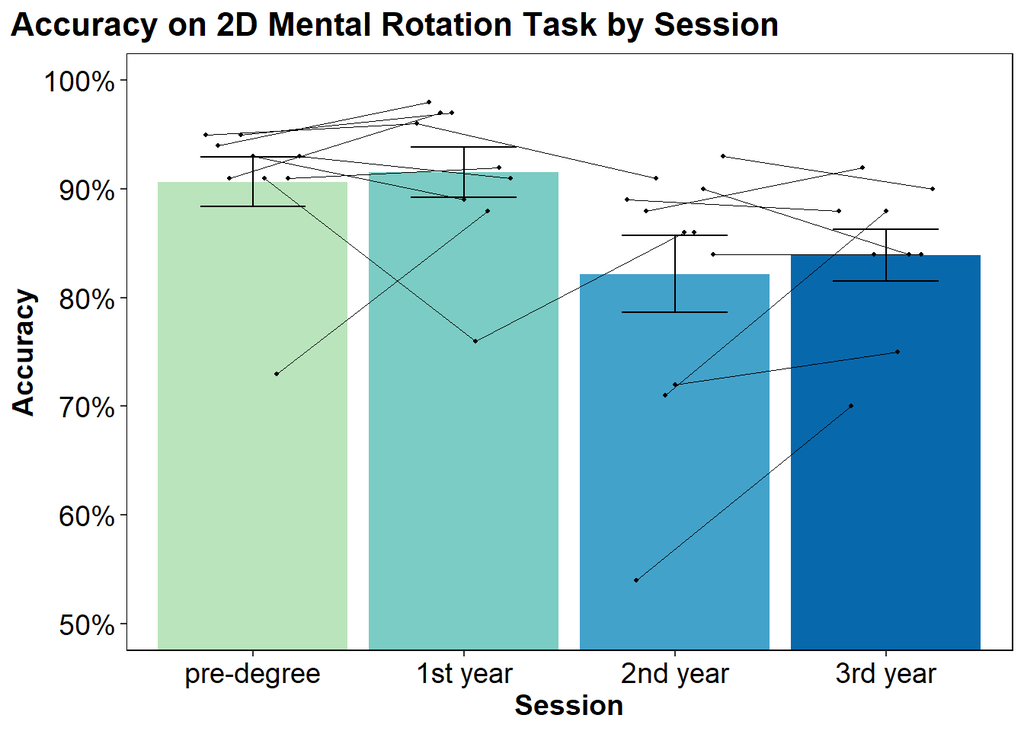

```r
# Jitter plot
J1 <- apt %>%
  group_by(session) %>%
  filter(!is.na(mr2d_acc)) %>%
  summarize(mean=mean(mr2d_acc), sd = sd(mr2d_acc), se=std.error(mr2d_acc)) %>%
  ggplot(aes(x = session, y = mean, fill = session)) +
  coord_cartesian(ylim = c(0.5, 1)) +
  geom_bar(stat = 'identity', position = position_dodge()) +
  theme_minimal() +
  scale_fill_manual(values = c("#bae4bc", "#7bccc4", "#43a2ca", "#0868ac")) +
  scale_y_continuous(labels = scales::percent_format(accuracy = 1L)) +
  labs(title = "Accuracy on 2D Mental Rotation Task by Session",
       x = "Session", y = "Accuracy")

limits <- aes(ymax = mean + se, ymin = mean - se)
J2 <- J1 + geom_errorbar(position = position_dodge(),
                          limits, size = 0.5, width = 0.5)

indiv <- apt %>%
  filter(!is.na(mr2d_acc)) %>%
  group_by(session, ppt) %>%
  summarise(mean = mean(mr2d_acc)) #, sd = sd(mr2d_acc)) # requires trial-level data

J3 <- J2 + geom_point(data=indiv, aes(group = ppt), size = 0.8,
                       shape = 19, position = pd) +
    geom_line(data = indiv, aes(group = ppt),
                      size = 0.1, position = pd)

( J4 <- J3 + theme_details )
```

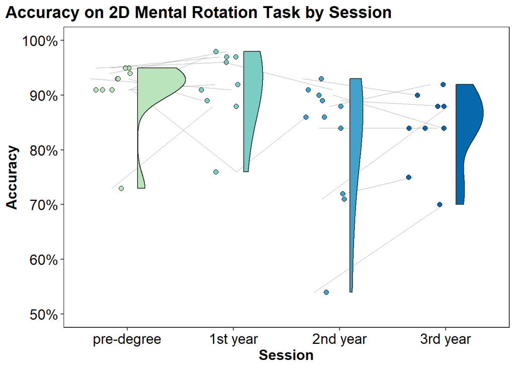

```r
# Raincloud + Jitter
( RJ <- apt %>%
  filter(!is.na(mr2d_acc)) %>%
  ggplot(aes(x = session, y = mr2d_acc, group = session, fill = session)) +
  geom_point(data=indiv, aes(x = session, y = mean, group = ppt),
             position = position_jitternudge(seed=42,jitter.width = .4, nudge.x = -.15),
                        size = 2, shape = 21) +
  geom_line(data = indiv, aes(x = session, y = mean, group = ppt),
                      size = 0.1, alpha = 0.3,
            position = position_jitternudge(seed=42,jitter.width = .4, nudge.x = -.15)) +
  geom_flat_violin(position = position_nudge(x = .1, y = 0),
                   adjust = 2, trim = TRUE, alpha = 1) +
  coord_cartesian(ylim = c(0.5, 1)) +
  scale_fill_manual(values = c("#bae4bc", "#7bccc4", "#43a2ca", "#0868ac")) +
  scale_y_continuous(labels = scales::percent_format(accuracy = 1L)) +
  labs(title = "Accuracy on 2D Mental Rotation Task by Session",
       x = "Session", y = "Accuracy") +
  theme_details )
```

#### Reaction Time

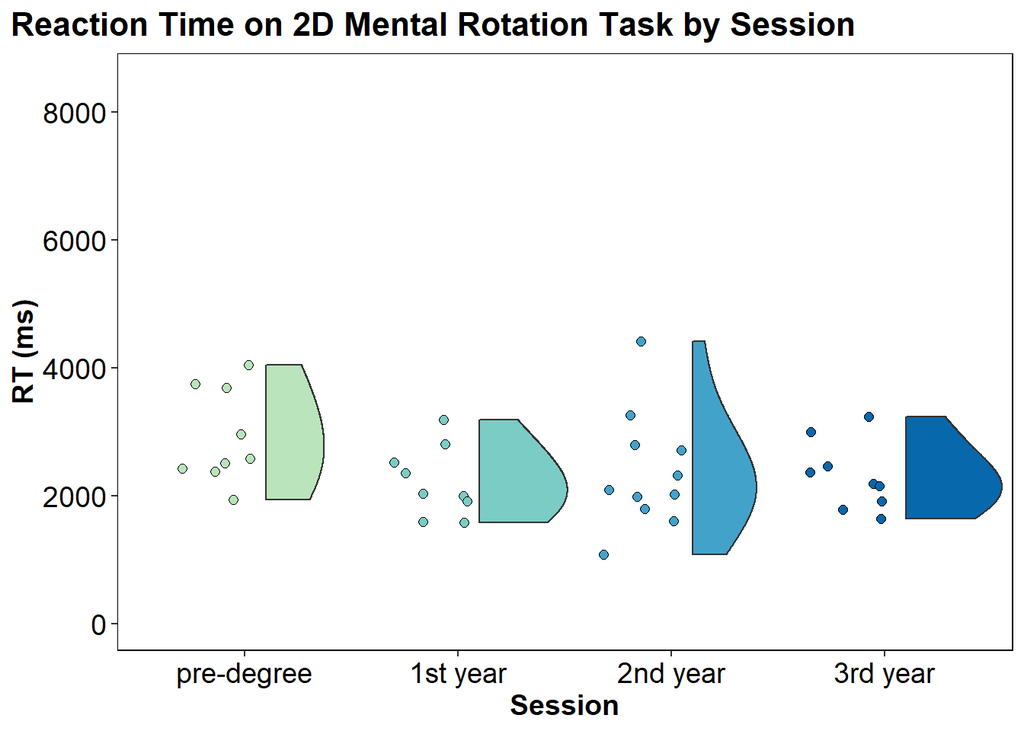

```r
# Raincloud plot
( R1 <- apt %>%
  filter(!is.na(mr2d_rt)) %>%
  ggplot(aes(x = session, y = mr2d_rt, group = session, fill = session)) +
  geom_flat_violin(position = position_nudge(x = .1, y = 0),
                   adjust = 2, trim = TRUE, alpha = 1) +
  geom_point(position = position_jitternudge(seed=42,jitter.width = .4, nudge.x = -.15),
                        size = 2, shape = 21) +
  coord_cartesian(ylim = c(0, 8500)) +
  scale_fill_manual(values = c("#bae4bc", "#7bccc4", "#43a2ca", "#0868ac")) +
  labs(title = "Reaction Time on 2D Mental Rotation Task by Session",
       x = "Session", y = "RT (ms)") +
  theme_details )
```

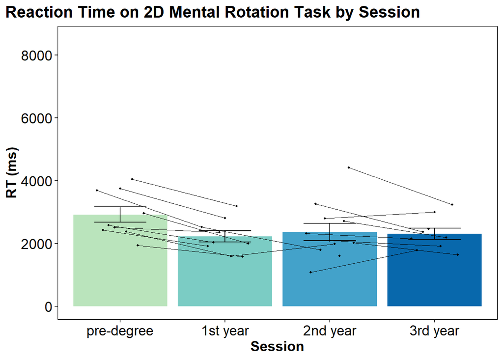

```r
# Jitter plot
J1 <- apt %>%
  group_by(session) %>%
  filter(!is.na(mr2d_rt)) %>%
  summarize(mean=mean(mr2d_rt), sd = sd(mr2d_rt), se=std.error(mr2d_rt)) %>%
  ggplot(aes(x = session, y = mean, fill = session)) +
  coord_cartesian(ylim = c(0, 8500)) +
  geom_bar(stat = 'identity', position = position_dodge()) +
  theme_minimal() +
  scale_fill_manual(values = c("#bae4bc", "#7bccc4", "#43a2ca", "#0868ac")) +
  labs(title = "Reaction Time on 2D Mental Rotation Task by Session",
       x = "Session", y = "RT (ms)")

limits <- aes(ymax = mean + se, ymin = mean - se)
J2 <- J1 + geom_errorbar(position = position_dodge(),
                          limits, size = 0.5, width = 0.5)

indiv <- apt %>%
  filter(!is.na(mr2d_rt)) %>%
  filter(ppt != "HW025") %>% ## removing extreme outlier
  group_by(session, ppt) %>%
  summarise(mean = mean(mr2d_rt)) #, sd = sd(mr2d_rt)) # requires trial-level data

J3 <- J2 + geom_point(data=indiv, aes(group = ppt), size = 0.8,
                       shape = 19, position = pd) +
    geom_line(data = indiv, aes(group = ppt),
                      size = 0.1, position = pd)

( J4 <- J3 + theme_details )
```

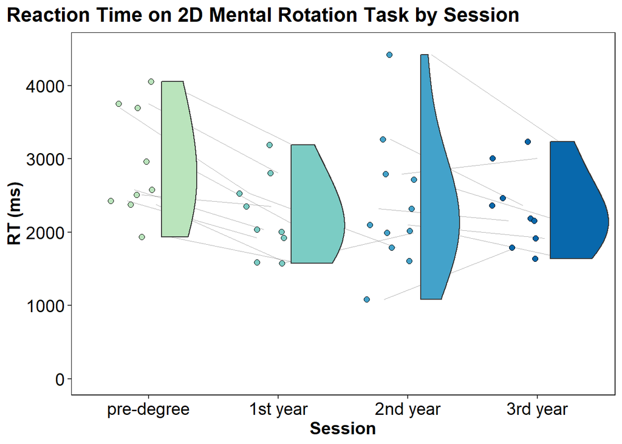

```r
# Raincloud + Jitter plot
( RJ <- apt %>%
  filter(!is.na(mr2d_rt)) %>%
  filter(ppt != "HW025") %>% ## removing extreme outlier
  ggplot(aes(x = session, y = mr2d_rt, group = session, fill = session)) +
  geom_line(data = indiv, aes(x = session, y = mean, group = ppt),
                      size = 0.1, alpha = 0.3, position = pd) +
  geom_flat_violin(position = position_nudge(x = .1, y = 0),
                   adjust = 2, trim = TRUE, alpha = 1) +
  geom_point(position = position_jitternudge(seed=42,jitter.width = .4, nudge.x = -.15),
                        size = 2, shape = 21) +
  scale_fill_manual(values = c("#bae4bc", "#7bccc4", "#43a2ca", "#0868ac")) +
  coord_cartesian(ylim = c(0, 4500)) +
  labs(title = "Reaction Time on 2D Mental Rotation Task by Session",
       x = "Session", y = "RT (ms)") +
  theme_details )
```

#### Speed-Accuracy Trade-off Score

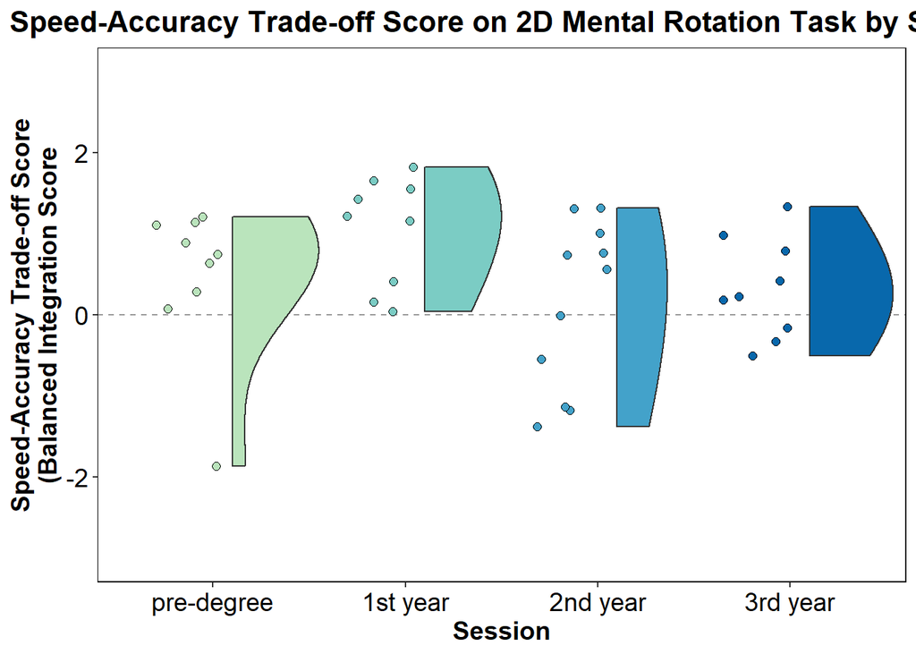

```r
# Raincloud plot
( R1 <- apt %>%
  filter(!is.na(mr2d_sats)) %>%
  ggplot(aes(x = session, y = mr2d_sats, group = session, fill = session)) +
  geom_hline(yintercept = 0, alpha = 0.4, linetype = "dashed") +
  geom_flat_violin(position = position_nudge(x = .1, y = 0),
                   adjust = 2, trim = TRUE, alpha = 1) +
  geom_point(position = position_jitternudge(seed=42,jitter.width = .4, nudge.x = -.15),
                        size = 2, shape = 21) +
  scale_fill_manual(values = c("#bae4bc", "#7bccc4", "#43a2ca", "#0868ac")) +
  coord_cartesian(ylim = c(-3, 3)) +
  labs(title = "Speed-Accuracy Trade-off Score on 2D Mental Rotation Task by Session",
       x = "Session",
       y = "Speed-Accuracy Trade-off Score\n(Balanced Integration Score") +
  theme_details )
```

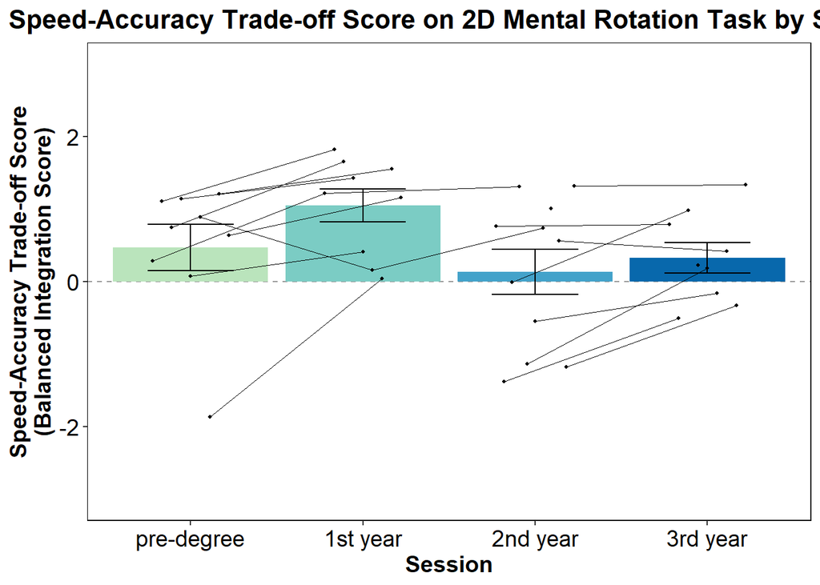

```r
# Jitter plot
J1 <- apt %>%
  group_by(session) %>%
  filter(!is.na(mr2d_sats)) %>%
  summarize(mean=mean(mr2d_sats), sd = sd(mr2d_sats), se=std.error(mr2d_sats)) %>%
  ggplot(aes(x = session, y = mean, fill = session)) +
  coord_cartesian(ylim = c(-3, 3)) +
  geom_hline(yintercept = 0, alpha = 0.4, linetype = "dashed") +
  geom_bar(stat = 'identity', position = position_dodge()) +
  theme_minimal() +
  scale_fill_manual(values = c("#bae4bc", "#7bccc4", "#43a2ca", "#0868ac")) +
  labs(title = "Speed-Accuracy Trade-off Score on 2D Mental Rotation Task by Session",
       x = "Session",
       y = "Speed-Accuracy Trade-off Score\n(Balanced Integration Score)")

limits <- aes(ymax = mean + se, ymin = mean - se)
J2 <- J1 + geom_errorbar(position = position_dodge(),
                          limits, size = 0.5, width = 0.5)

indiv <- apt %>%
  filter(!is.na(mr2d_sats)) %>%
  group_by(session, ppt) %>%
  summarise(mean = mean(mr2d_sats)) #, sd = sd(mr2d_rt)) # requires trial-level data

J3 <- J2 + geom_point(data=indiv, aes(group = ppt), size = 0.8,
                       shape = 19, position = pd) +
    geom_line(data = indiv, aes(group = ppt),
                      size = 0.1, position = pd)

( J4 <- J3 + theme_details )
```

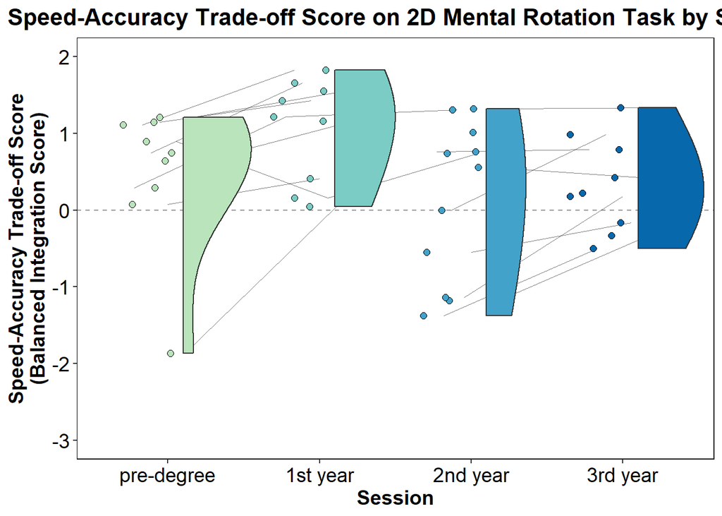

```r
( RJ <- apt %>%
  filter(!is.na(mr2d_sats)) %>%
  ggplot(aes(x = session, y = mr2d_sats, group = session, fill = session)) +
  geom_hline(yintercept = 0, alpha = 0.4, linetype = "dashed") +
  geom_line(data = indiv, aes(x = session, y = mean, group = ppt),
                      size = 0.1, alpha = 0.5, position = pd) +
  geom_flat_violin(position = position_nudge(x = .1, y = 0),
                   adjust = 2, trim = TRUE, alpha = 1) +
  geom_point(position = position_jitternudge(seed=42,jitter.width = .4, nudge.x = -.15),
                        size = 2, shape = 21) +
  scale_fill_manual(values = c("#bae4bc", "#7bccc4", "#43a2ca", "#0868ac")) +
  coord_cartesian(ylim = c(-3, 2)) +
  labs(title = "Speed-Accuracy Trade-off Score on 2D Mental Rotation Task by Session",
       x = "Session",
       y = "Speed-Accuracy Trade-off Score\n(Balanced Integration Score)") +
  theme_details )
```

### 3D Mental Rotation

How does performance on the 3D Mental Rotation task change over time?

#### Accuracy

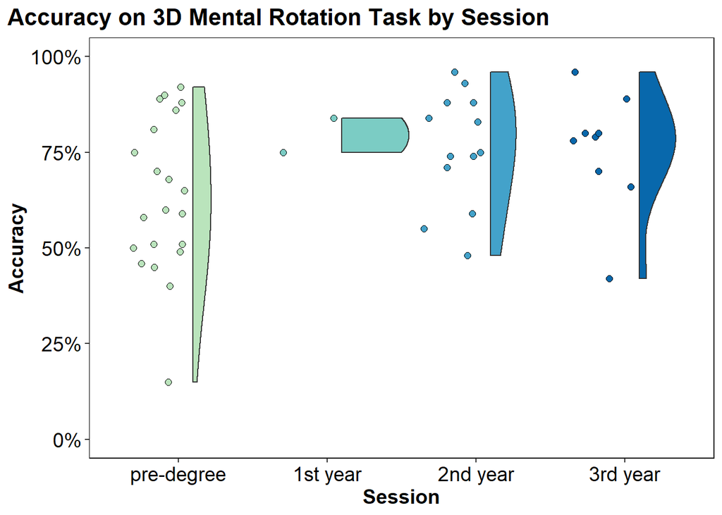

```r
# Raincloud plot
( R1 <- apt %>%
  filter(!is.na(mr3d_acc)) %>%
  #filter(session != "1st year") %>% #only 2 ppts at 2nd session>filter out
  ggplot(aes(x = session, y = mr3d_acc, group = session, fill = session)) +
  geom_flat_violin(position = position_nudge(x = .1, y = 0),
                   adjust = 2, trim = TRUE, alpha = 1) +
  geom_point(position = position_jitternudge(seed=42,jitter.width = .4, nudge.x = -.15),
                        size = 2, shape = 21) +
  coord_cartesian(ylim = c(0, 1)) +
  scale_fill_manual(values = c("#bae4bc", "#7bccc4", "#43a2ca", "#0868ac")) +
  scale_y_continuous(labels = scales::percent_format(accuracy = 1L)) +
  labs(title = "Accuracy on 3D Mental Rotation Task by Session",
       x = "Session", y = "Accuracy") +
  theme_details )
```

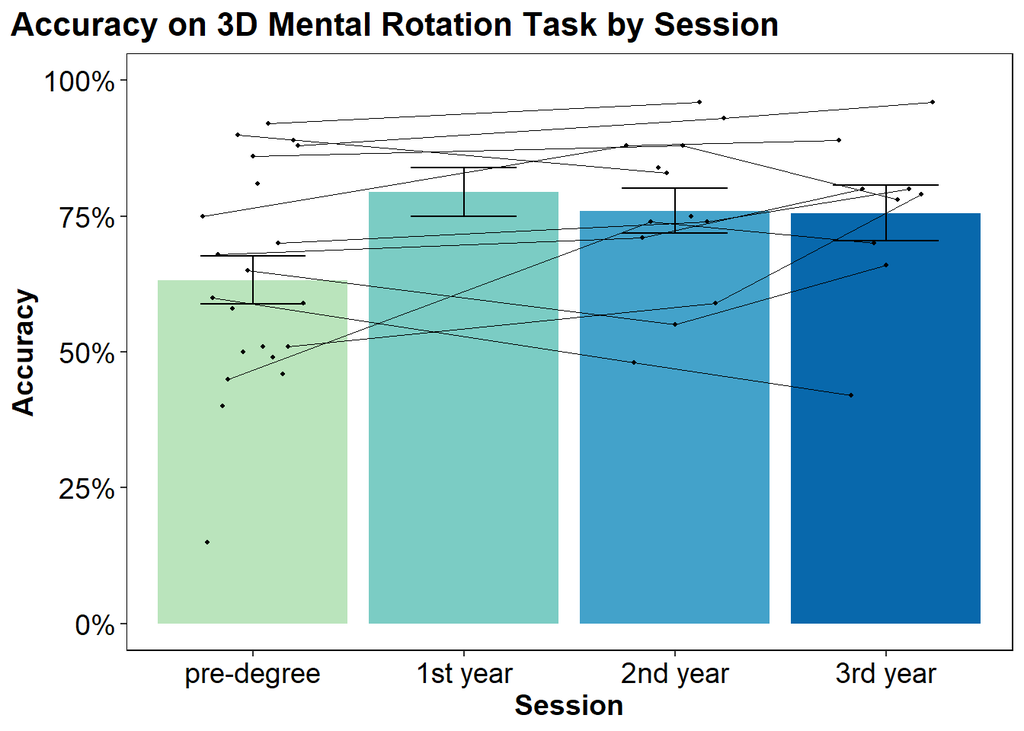

```r
# Jitter plot
J1 <- apt %>%
  group_by(session) %>%
  filter(!is.na(mr3d_acc)) %>%
  #filter(session != "1st year") %>% #only 2 ppts at 2nd session>filter out
  summarize(mean=mean(mr3d_acc), sd = sd(mr3d_acc), se=std.error(mr3d_acc)) %>%
  ggplot(aes(x = session, y = mean, fill = session)) +
  coord_cartesian(ylim = c(0, 1)) +
  geom_bar(stat = 'identity', position = position_dodge()) +
  theme_minimal() +
  scale_fill_manual(values = c("#bae4bc", "#7bccc4", "#43a2ca", "#0868ac")) +
  scale_y_continuous(labels = scales::percent_format(accuracy = 1L)) +
  labs(title = "Accuracy on 3D Mental Rotation Task by Session",
       x = "Session", y = "Accuracy")

limits <- aes(ymax = mean + se, ymin = mean - se)
J2 <- J1 + geom_errorbar(position = position_dodge(),
                          limits, size = 0.5, width = 0.5)

indiv <- apt %>%
  filter(!is.na(mr3d_acc)) %>%
  filter(session != "1st year") %>% #only 2 ppts at 2nd session>filter out
  group_by(session, ppt) %>%
  summarise(mean = mean(mr3d_acc)) #, sd = sd(mr3d_acc)) # requires trial-level data

J3 <- J2 + geom_point(data=indiv, aes(group = ppt), size = 0.8,
                       shape = 19, position = pd) +
    geom_line(data = indiv, aes(group = ppt),
                      size = 0.1, position = pd)

( J4 <- J3 + theme_details )
```

#### Reaction Time

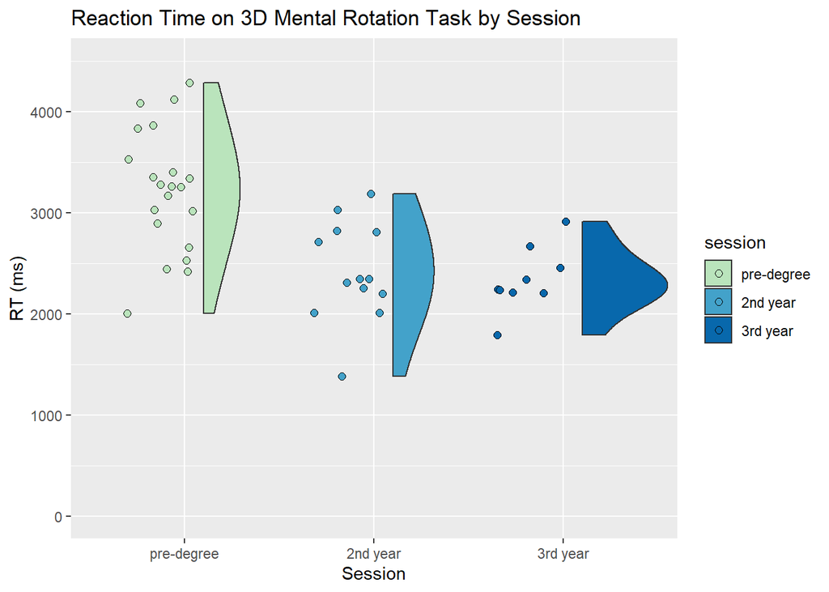

```r
# Raincloud plot
( R1 <- apt %>%
  filter(!is.na(mr3d_rt)) %>%
  filter(session != "1st year") %>% #only 2 ppts at 2nd session>filter out
  ggplot(aes(x = session, y = mr3d_rt, group = session, fill = session)) +
  geom_flat_violin(position = position_nudge(x = .1, y = 0),
                   adjust = 2, trim = TRUE, alpha = 1) +
  geom_point(position = position_jitternudge(seed=42,jitter.width = .4, nudge.x = -.15),
                        size = 2, shape = 21) +
  coord_cartesian(ylim = c(0, 4500)) +
  scale_fill_manual(values = c("#bae4bc", "#43a2ca", "#0868ac")) +
  labs(title = "Reaction Time on 3D Mental Rotation Task by Session",
       x = "Session", y = "RT (ms)") )
```

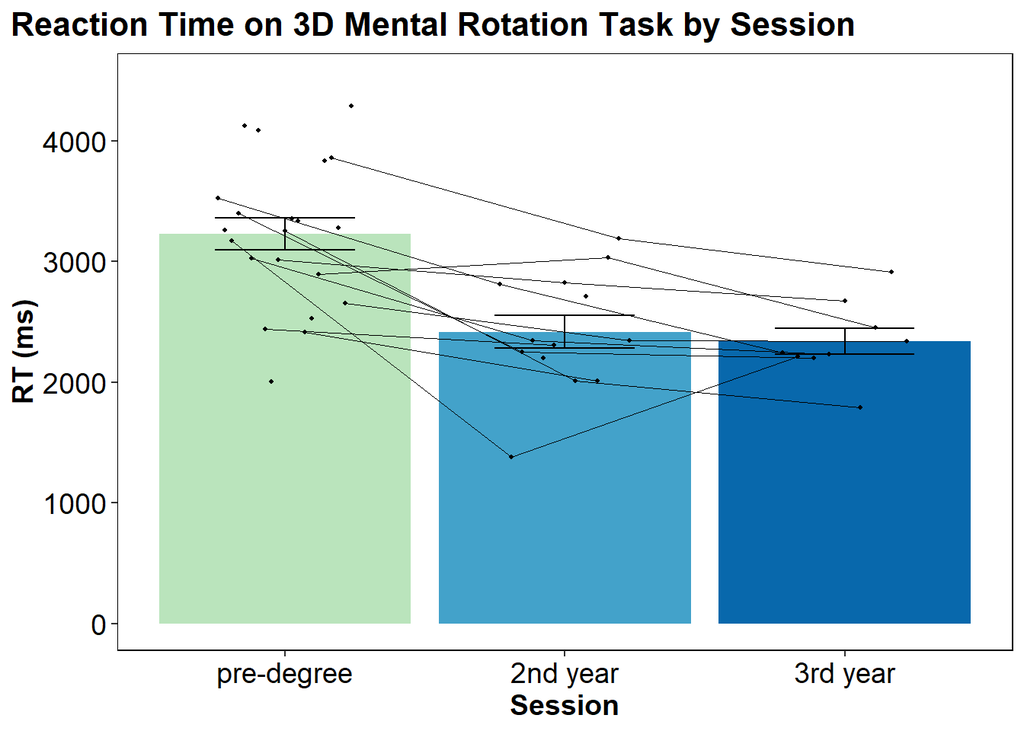

```r
# Jitter plot
J1 <- apt %>%
  group_by(session) %>%
  filter(!is.na(mr3d_rt)) %>%
  filter(session != "1st year") %>% #only 2 ppts at 2nd session>filter out
  summarize(mean=mean(mr3d_rt), sd = sd(mr3d_rt), se=std.error(mr3d_rt)) %>%
  ggplot(aes(x = session, y = mean, fill = session)) +
  coord_cartesian(ylim = c(0, 4500)) +
  geom_bar(stat = 'identity', position = position_dodge()) +
  theme_minimal() +
  scale_fill_manual(values = c("#bae4bc", "#43a2ca", "#0868ac")) +
  labs(title = "Reaction Time on 3D Mental Rotation Task by Session",
       x = "Session", y = "RT (ms)")

limits <- aes(ymax = mean + se, ymin = mean - se)
J2 <- J1 + geom_errorbar(position = position_dodge(),
                          limits, size = 0.5, width = 0.5)

indiv <- apt %>%
  filter(!is.na(mr3d_rt)) %>%
  filter(session != "1st year") %>% #only 2 ppts at 2nd session>filter out
  group_by(session, ppt) %>%
  summarise(mean = mean(mr3d_rt)) #, sd = sd(mr3d_rt)) # requires trial-level data

J3 <- J2 + geom_point(data=indiv, aes(group = ppt), size = 0.8,
                       shape = 19, position = pd) +
    geom_line(data = indiv, aes(group = ppt),
                      size = 0.1, position = pd)

( J4 <- J3 + theme_details )
```

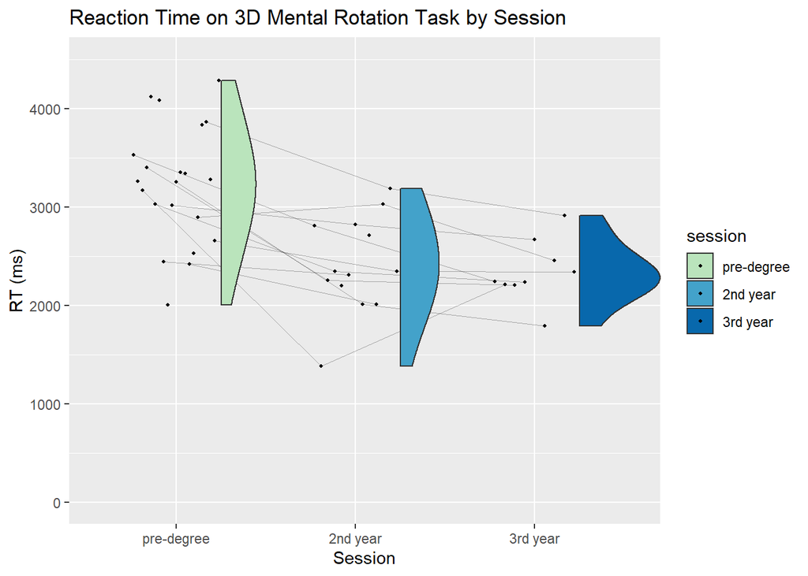

```r
# Raincloud + Jitter
( RJ <- apt %>%
  filter(!is.na(mr3d_rt)) %>%
  filter(session != "1st year") %>% #only 2 ppts at 2nd session>filter out
  ggplot(aes(x = session, y = mr3d_rt, group = session, fill = session)) +
  geom_line(data = indiv, aes(x = session, y = mean, group = ppt),
                      size = 0.1, alpha = 0.3, position = pd) +
  geom_flat_violin(position = position_nudge(x = .25, y = 0),
                   adjust = 2, trim = TRUE, alpha = 1) +
  geom_point(data=indiv, aes(x = session, y = mean, group = ppt), size = 0.8,
                       shape = 19, position = pd) +
  scale_fill_manual(values = c("#bae4bc", "#43a2ca", "#0868ac")) +
  coord_cartesian(ylim = c(0, 4500)) +
  labs(title = "Reaction Time on 3D Mental Rotation Task by Session",
       x = "Session", y = "RT (ms)") )
```